# Flu Correlates of Protection

Author

Savannah L. Miller

# General/Background

## “Immunologic correlates of protection induced by vaccination” (S. A. Plotkin 2001)

## “Correlates of vaccine-induced immunity” (Stanley A. Plotkin 2008)

## “Correlates of protection induced by vaccination” (Stanley A. Plotkin 2010)

## “Nomenclature for immune correlates of protection after vaccination” (Stanley A. Plotkin and Gilbert 2012)

## “COVID-19 vaccine update: vaccine effectiveness, SARS-CoV-2 variants, boosters, adverse effects, and immune correlates of protection” (Chi et al. 2022)

## “Recent updates on correlates of vaccine-induced protection” (**plotkin22?**)

## “Immune correlates of protection for SARS-CoV-2, Ebola and Nipah virus infection” (Escudero-Pérez, Lawrence, and Castillo-Olivares 2023)

# Models

## “A model for immunological correlates of protection” (Dunning 2006)

## “Evaluating a surrogate endpoint at three levels, with application to vaccine development” (**gilbert08a?**)

## “Updates on immunologic correlates of vaccine-induced protection” (Stanley A. Plotkin 2020)

## “Correlates of Vaccine-Induced Protection against SARS-CoV-2” (Koch et al. 2021)

## “Correlates of protection against SARS‐CoV‐2 infection and COVID‐19 disease” (Goldblatt et al. 2022)

## “The role of serum haemagglutination-inhibiting antibody in protection against challenge infection with influenza A2 and B viruses” (Hobson et al. 1972)

- 1032 adults - serum HAI taken right before live virus challenge
- Participants came from two different trials, but in both case, challenges were administered 2-3 weeks *after* completed vaccination (whatever vaccination they may have received)
- Serum samples taken both before and (two weeks) after challenge, and nasal swabs for virus isolation were taken 48 hours after challenge
- **50% Protective Dose** (PD50) - the titer at which the infection rate is reduced to half the maximum observed rate
  - Influenza B: Approximately 1/18 (Infection rate was not much higher in those with no detectable titer than in those with lowest detectable titer - 1/6)
  - Influenza A: 1/18-1/36 (multiple A studies)
- Discussion - specify that this cannot be used to identify a causal relationship, and that HI is often only part of a greater immune response
  - HI appears to have stronger relationship than NI, but may specifically be less relevant in flu B - not enough data to tell in this study

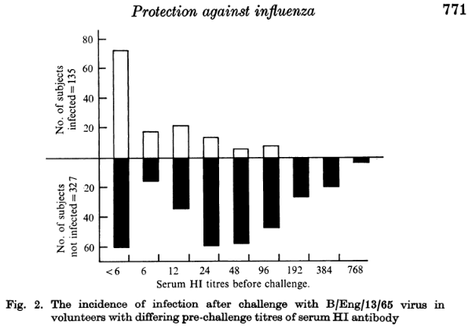

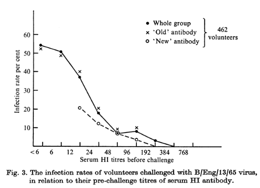

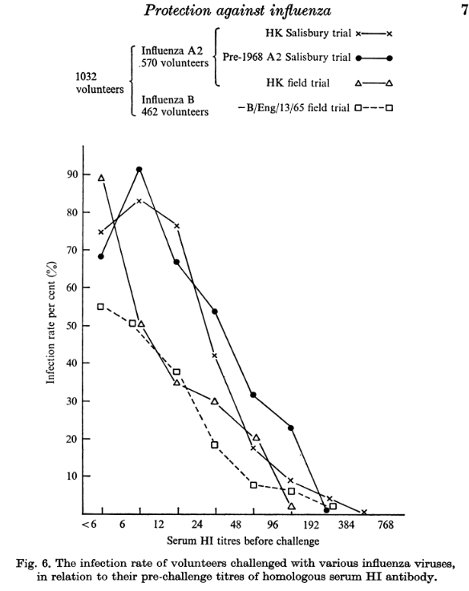

## Determinants of immunity to influenza infection in man (Potter and Oxford 1979)

- Review
- “Most results indicate that, following immunization with inactivated virus vaccines, HI antibody titres of approximately 1:30-1:40 represent the 50% protective level of antibody (Hobson et al. 1972; Potter et al. 1977a), and similar results have been obtains following live virus infection (McDonald et al. 1962; Andrews et al. 1966).”

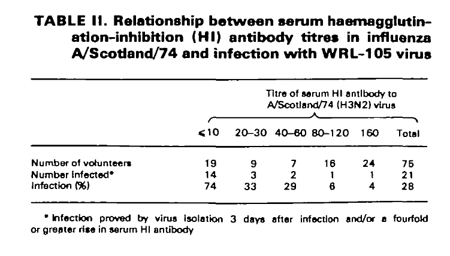

## “Interpretation of responses and protective levels of antibody against attenuated influenza A viruses using single radial haemolysis” (Al-Khayatt, Jennings, and Potter 1984)

- 50% PT: 42 for H1N1, 44 for H3N2
- “50% protection against infection of man with H1N1 or H3N2 influenza virus strains”

## “Correlates of protection to influenza virus, where do we go from here?” (Cox 2013)

- Notes later

## “Immunological assessment of influenza vaccines and immune correlates of protection” (Reber and Katz 2013)

- Notes later

## “The establishment of surrogates and correlates of protection: Useful tools for the licensure of effective influenza vaccines?” (Ward et al. 2018)

- Notes later

## “Call for a paradigm shift in the design of universal influenza vaccines by harnessing multiple correlates of protection” (Jang and Seong 2020)

- Notes later

## “Meeting report and review: Immunological assays and correlates of protection for next-generation influenza vaccines” (Krammer et al. 2020)

- Notes later

# Models and Identified CoP Relationships

## “On the relationship between mean antibody level, seroprotection and clinical protection from influenza” (**nauta2009a?**)

- Modeling/simulations - no real results
- More notes later

## “Relationship between haemagglutinationinhibiting antibody titres and clinical protection against influenza: development and application of a bayesian random-effects model” (Coudeville, Bailleux, et al. 2010)

- Used 15 papers from 1945-2006; 6 challenge studies, 5 clinical trials, and 4 cohort studies
- Models tried:
  - Simple model for one study, no censorship and no covariates
  - A random-effects model with uncensored data with covariates
  - A random-effects model with interval-censored data with covariates
- Used MCMC methods for parameter estimation
- Determined simplest model (using only HAI titer) was sufficient for predicting protection

| Model Term | Meaning |
| --- | --- |
| $\lambda$ | baseline risk that an individual develops influenza in the absence of any HI-related protection |
| $T_j$ | HI titer |
| $\theta$ | associated vector of parameters |
| $P(y_j = 1)$ | the risk that an individual develops influenza |
| $\pi (T_j, \theta)$ | HI-protection curve |
| 50% PT | 50% protection titer |
| $X_i$ | vector of binary variables |
| $(\alpha_c, \beta_c)$ | random effects associated with $X_i$ |
| $\lambda_i$ | baseline risks unrelated to HI protection curve |

Estimation of the risk that an individual develops influenza in the presence HI antibodies:

$$P(Y_j = 1 | T_j, \theta, \lambda) = \lambda(1 - \pi(T_j, \theta))$$

Simple model for one study, no censorship, and no covariates:

$$\pi(T_j, \theta) = \frac{e^{\beta(\log(T_j) - \alpha)}}{1 + e^{\beta(\log(T_j) - \alpha)}}$$

$$= 1 - \frac{1}{1 + e^{\beta(\log(T_j) - \alpha)}}$$

- $\alpha$ is closely linked to the 50% protection titer and can be interpreted as a location parameter for the HI protection curve

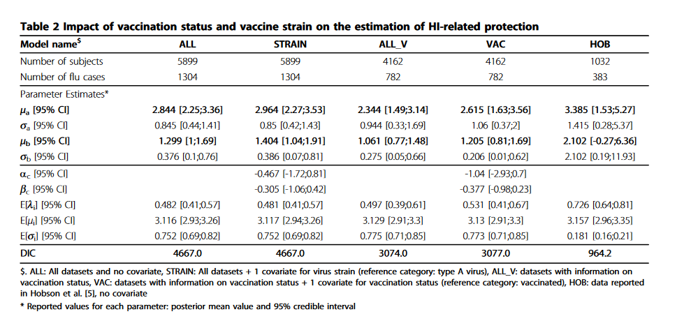

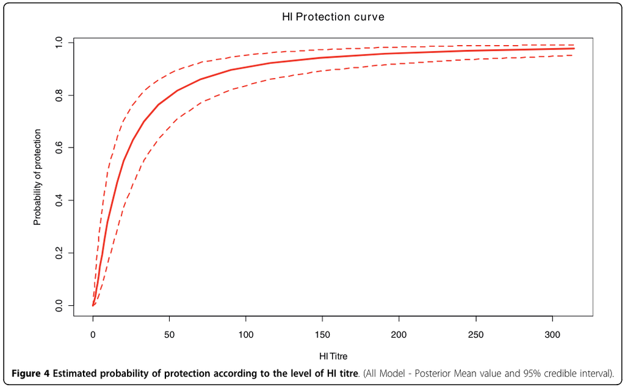

### “A new approach to estimate vaccine efficacy based on immunogenicity data applied to influenza vaccines administered by the intradermal or intramuscular routes” (Coudeville, Andre, et al. 2010)

- Part two of (Coudeville, Bailleux, et al. 2010)
- Comparing intradermal vaccine (INTANZA/IDFlu) to standard TIV IM vaccine

[output not shown]

$$P(\text{influenza}) = P_0[1 - \pi(T_i)]$$
$$VE_{HI} = 1 - \frac{\sum_{j=1}^N[1-\pi(T_j^{post})]}{\sum_{j=1}^N[1-\pi(T_j^{pre})]}$$

$$AIVE_{ID/IM} = VE_{ID} - VE_{IM}$$
$$RIVE_{ID/IM} = (VE_{ID}-VE_{IM})/VE_{IM}$$

## “Hemagglutination inhibition antibody titers as a correlate of protection for inactivated influenza vaccines in children” (Black et al. 2011)

- 2007-2008 and 2008-2009 seasons
- 4707 influenza vaccine-naive children 6-72 months randomized 2:2:1 into:
  - MF-59 –adjuvanted inactivated influenza vaccine (ATIV, Fluad)
  - Subunit TIV (TIV control, Influsplit, GSK, Rixensart, Belgium)
  - Saline placebo
- Active surveillance for ILI with RT-PCR confirmation
- Serum samples obtained for a subset of 777 children at:
  - enrollment,
  - on day 29 when the second dose was administered,
  - at **day 50** (approximately 3 weeks after dose 2), and
  - at day 180 after receipt of 2 doses of vaccine or placebo
- Linear **logistic regression** model fitted with vaccine group only included as predictor
- Second logistic regression model was fit, which controlled for log2 day 50 antibody titer and vaccine group to determine the effect of antibody titer on the occurrence of influenza
- Relationship between the occurrence of influenza and H3N2 antibody titer level was modeled using the logistic regression model advocated by **Dunning** that accommodates both antibody titers and factors independent of antibody titers
  - Probability that a subject develops influenza is the probability that the subject is susceptible multiplied by the probability that susceptible individuals develop disease. Susceptibility is characterized by the probability $\lambda$, and the probability that a subject with titer t is protected is represented by a 2-parameter logit function, with $\alpha$ and $\beta$ denoting the location and the scale parameters of interest, respectively
- Estimated CoP at time of “challenge” (time the diagnostic viral swab was obtained) using day 50 titer, estimated half life of 111 days and assuming logarithmic decay
- Protective titers (at fixed time 50 days):
  - 50%: 1:110
  - 70%: 1:215
  - 80%: 1:330
  - 90%: 1:629
  - Traditional 1:40 was associated with 22% protection
- Protective titers (at time of “challenge”):
  - 50%: 1:85 (95% CI 35.6, 137.9)
  - 90%: 1:302 (95% CI 176.9, 439.2)

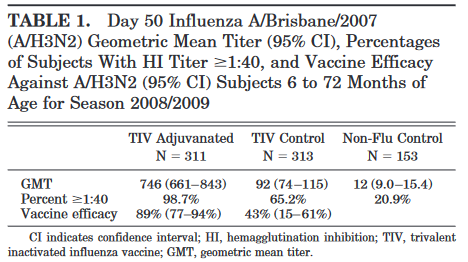

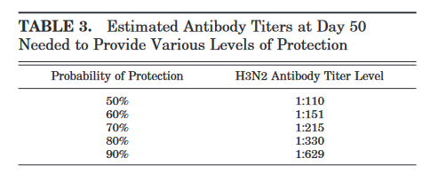

## “Influenza hemagglutination-inhibition antibody titer as a correlate of vaccine-induced protection” (Ohmit et al. 2011)

- GMT, %(+) at titers, etc. - simpler methods, take notes later

## “Estimation of the assocation between antibody titers and protection against confirmed influenza virus infection in children” (Ng et al. 2013)

## “Estimation of the assocation between antibody titers and protection against confirmed influenza virus infection in children” (Ng et al. 2013)

- Children aged 6-17 in Hong Kong given TIV or placebo and followed for 9-12 months (Kiddivax)
  - The TIV contained 15 μg of hemagglutinin for each of the A/Brisbane/59/2007(H1N1)–like, A/Brisbane/10/2007(H3N2)like, and B/Brisbane/60/2008–like (Victoria lineage) strains.
- Serum samples collected pre-vaccine, one month post-vaccine, at end of follow up/study
  - 25% of participants had additional samples taken midstudy
- 465 TIV, 308 placebo
- Examined waning rates in absence of infection using log-linear regression models based on all postvaccination, midstudy, and end-of-study antibody titer data (separate for TIV vs placebo, excluding all possible infections)
  - Allowed for different wanting rates in those 6-8 and 9-17 years old
- **Cox proportional hazards model** estimating correlation of HAI titer over time with protection against PCR-confirmed infection, assessing if association different for TIV vs placebo group and allowing for time-varying incidence in the community
- Protective titers (accounting for waning and time-varying community risk of infection):
  - 1:40 against A(H1N1)pdm09: 48% (95% CI 30, 62)
  - 1:40 against B(Victoria): 55% (95% CI 32, 70)

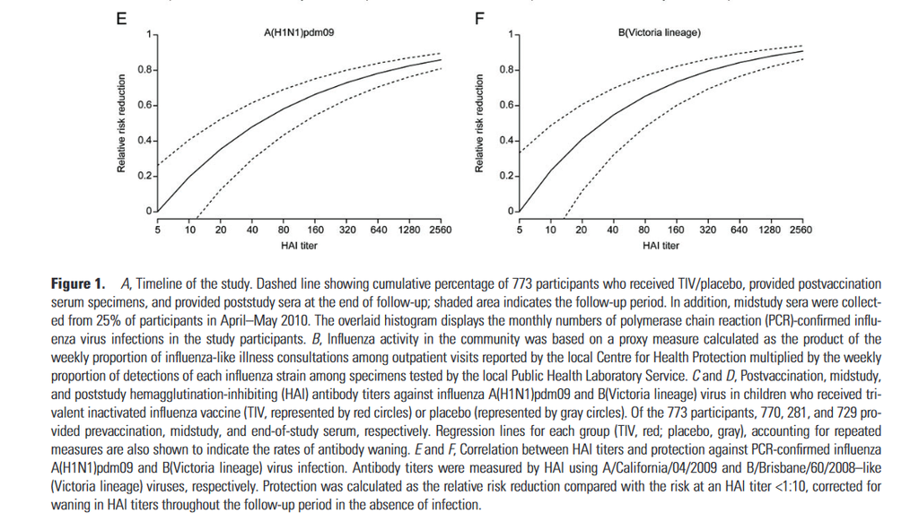

## “Serological responses following influenza A(H7N9) virus infection” (Freeman and Cowling 2014)

- Letter to the editor - notes later

## “Association between antibody titers and protection against influenza virus infection within households” (Tsang et al. 2014)

- Recruited those presenting at outpatient clinics with ARI within 48 hours of onset and who lived in a household with at least two others - those positive for flu A or B were followed up with along with their households
- Serum samples collected at initial visit from consenting subgroup of household contacts
- Modeling: log-linear, logistic, nonparametric models fit for relationship between protection and antibody titer (log-linear was main model, others fit to assess whether results were robust with respect to model)

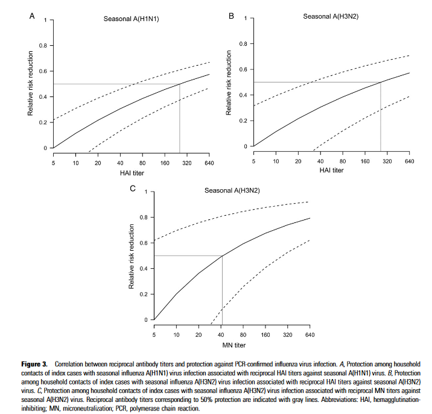

- Totally different 50%PT - “One possible explanation for this observation is that influenza virus infections in a household index case result in more intense exposures among susceptible household contact”

## “Some extension in continuous models for immunological correlates of protection” (Dunning et al. 2015)

- More stat heavy - notes later

## “Correlates of protection against influenza in the elderly: Results from an influenza vaccine efficacy trial” (Dunning et al. 2016)

## “Extrapolating theoretical efficacy of inactivated influenza A/H5N1 virus vaccine from human immunogenicity studies” (Feldstein et al. 2016)

- Same as my paper - notes later

## “The Household Influenza Vaccine Effectiveness Study: Lack of Antibody Response and Protection Following Receipt of 2014-2015 Influenza Vaccine” (Petrie et al. 2017)

- Household study based out of University of Michigan
- Households had $\ge$ 3 members, including $\ge$ 2 children under 18
- Serum collected at enrollment and surveillance conducted October 2014-May 2015, RT-PCR used to confirm flu cases
- **Cox proportional hazards models** adjusted for age and high-risk health status
  - Robust variances using sandwich estimators to account for household clustering
  - No curve or 50% PT reported

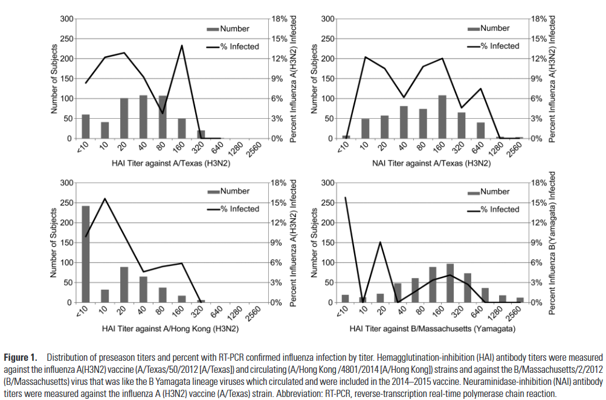

## “Age-specific differences in the dynamics of protective immunity to influenza” (Ranjeva et al. 2019)

- Notes later - maybe handelgroup paper?

## “Maternal antibodies against influenza in cord blood and protection against laboratory-confirmed influenza in infants” (Benjamin J. Cowling et al. 2020)

- “Previous studies have shown a mean half-life of 40–58 days in maternal antibodies after maternal influenza vaccination, which may confer the most protection in the first 4–6 months of life. A more recent study found that vaccine efficacy was highest among infants 8 weeks of age or younger and gradually decreased with increasing age.”
- Maternal cord blood HAI assays, followed children for first 6 months
- **Cox proportional hazards model** for time from birth to infection, $\log_2$ titer and risk of PCR-confirmed infection
  - Adjusted for variation over calendar time in risk of infection by type/subtype based on community surveillance data
- Infants protected from influenza B infection when cord blood HAI titer against B/Yamagata was 40 or greater
  - 83% (95% CI 44-95%) reduction in risk of infection compared to titer <10
- No association for H3N2, not enough H1N1 infections
- Only 26 infections total

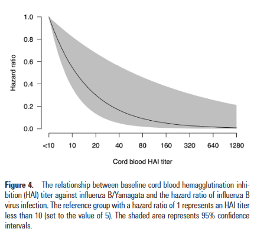

## “Distinguishing causation from correlation in the use of correlates of protection to evaluate and develop influenza vaccines” (**lim2020?**)

- Mechanistic vs nonmechanistic CoPs -> “Mediators of protection” vs “correlates of protection”
- Causation vs correlation
- More notes later

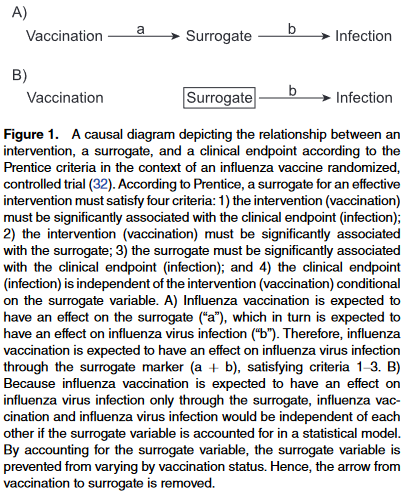

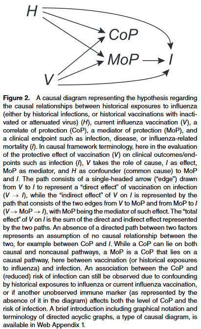

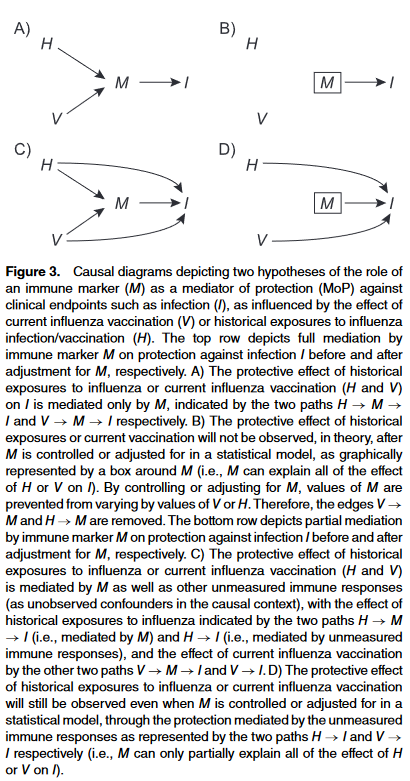

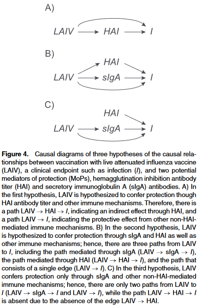

## “A method to estimate probability of disease and vaccine efficacy from clinical trial immunogenicity data” (Dudášová et al. 2021)

- PoDBAY
- Probability of disease vs probability of protection
- R package
- Not a flu-specific paper, but does have a flu example
- Have discussed this at IDIG before

$$PoD = p_{max} \frac{(\frac{et50}{titer})^\lambda}{1 + (\frac{et50}{titer})^\lambda}, for \space titers > 0$$

$$PoD = pmax, for \space titers <= 0$$

- pmax = maximum PoD $\approx \lambda$?
- et50 = titer values corresponding to pmax/2 value, PoD(et50) = pmax/2 $\approx$ 50%PT
- $\lambda$ = slope

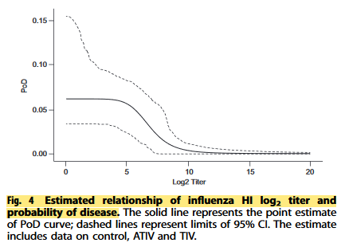

- Similar 50% to Black et al (same data, just new model)

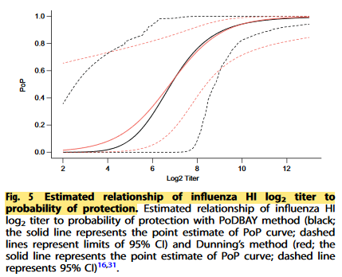

## “Baseline innate and T cell populations are correlates of protection against symptomatic influenza virus infection independent of serology” (Mettelman et al. 2023)

- Baseline serum and peripheral blood samples from 206 SHIVERS-II participants (2018)
  - Vaccine status, infection outcomes, demographics
  - Baseline is preseason for non-vaccinated and 14 days after vaccination for vaccinated
  - Symptomatic and cryptic infections
  - **Univariate analyses and multivariate partition and regression models**
    - Univariate - ROC curves
  - **Predictive (random forest) modeling**
    - Base model with demographic and serologic data
    - Lymphoid model with base model + cell populations from lymphoid/functional panel
    - Myeloid model with base model + cell populations from myeloid panel
    - Combined model with all variables
    - Myeloid only model
    - Lymphoid + myeloid model

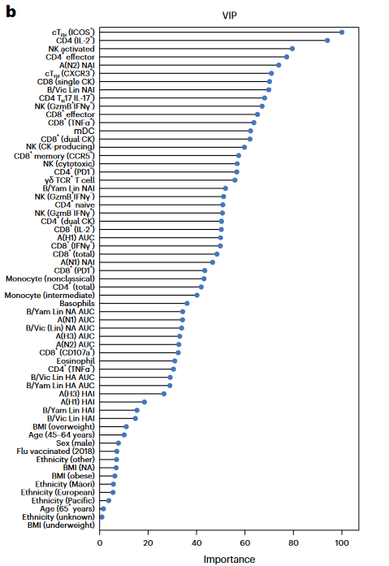

Relative importance of each baseline covariate in the combined random forest model

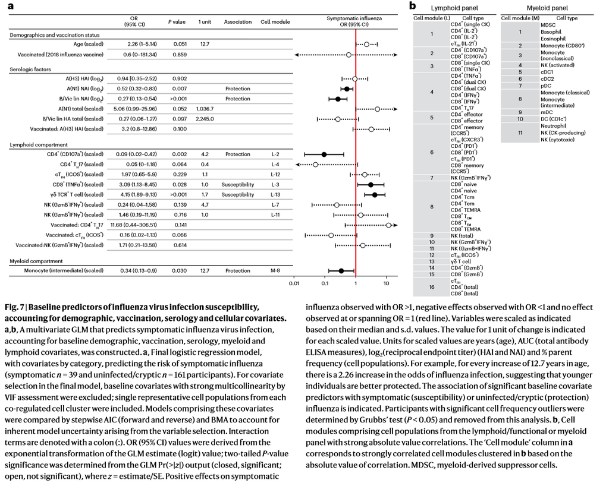

## “A Multicenter, Controlled Human Infection Study of Influenza A(H1N1)pdm09 in Healthy Adults” (Ortiz et al. 2023)

- GMTs, notes later

## “Hemagglutination inhibition antibody titers mediate influenza vaccine efficacy against symptomatic influenza A(H1N1), A(H3N2), and B/Victoria infections” (Lim et al. 2024)

- Causal mediation analyses
- Children aged 3-8 in the Dominican Republic, Honduras, Panama, Bangladesh, Lebanon, the Philippines, Thailand, and Turkey given either one or two doses of QIV or active comparator (hep A)
  - Two doses of QIV 28 days apart if they were not considered “primed” by natural infection or previous vaccination, one dose if they were considered primed
- Serum samples collected 28 days after vaccination, passive surveillance for ILI with influenza PCR confirmation
- Analysis:
  - “Total effect” of vaccination against influenza virus comprised of “indirect effect” mediated by immune marker like HAI titer and “direct effect” mediated by other protective immune mechanisms
  - Total effect estimated with **proportional hazards model** with time between last dose of vaccination and infection as outcome
  - Direct effect (hazard ratio for QIV) estimated in three steps:
    1. **Logistic regression** with vaccination status as outcome and log HAI titers, age, region, and priming status as predictors
    2. Coefficients from step 1 are used to predict odds ratio of vaccination for each participant and weights for vaccinated participants constructed as inverse of these odds ratios
    3. **Weighted proportional hazards** model fitted with outcome being time between vaccination and infection with covariates age, vaccine status, region, and priming status, and weights from step 2 used as regression weights
  - Indirect effect calculated as ratio of total and direct effects

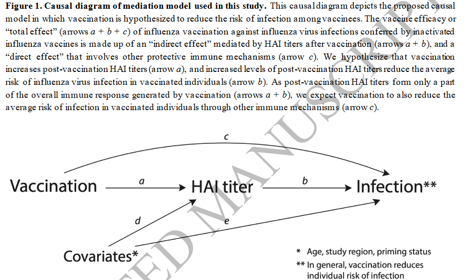

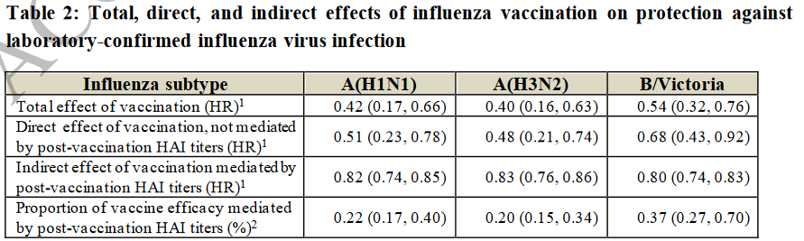

## “Anti-neuraminidase immunity in the combat against influenza” (Zhang et al. 2024)

## Miscellaneous flu serology papers

## “Inferring influenza infection attack rate from seroprevalence data” (Wu et al. 2014)

## “Individual correlates of infectivity of influenza A virus infections in households” (Tsang et al. 2016)

## “Influenza hemagglutination-inhibition antibody titer as a mediator of vaccine-induced protection for influenza B” (Benjamin J. Cowling et al. 2019)

## “The value of neuraminidase inhibition antibody titers in influenza seroepidemiology” (Benjamin J. Cowling and Sullivan 2019)

## “Risk factors and attack rates of seasonal influenza infection: Results of the Southern Hemisphere Influenza and Vaccine Effectiveness Research and Surveillance (SHIVERS) seroepidemiologic cohort study” (Huang et al. 2019)

## “Life course exposures continually shape antibody profiles and risk of seroconversion to influenza” (Yang et al. 2020)

Al-Khayatt, R., R. Jennings, and C. W. Potter. 1984. “Interpretation of Responses and Protective Levels of Antibody Against Attenuated Influenza A Viruses Using Single Radial Haemolysis.” *J Hyg (Lond)* 93 (2): 301–12. https://www.ncbi.nlm.nih.gov/pmc/articles/PMC2129441/.

Black, Steven, Uwe Nicolay, Timo Vesikari, Markus Knuf, Giuseppe Del Giudice, Giovanni Della Cioppa, Theodore Tsai, Ralf Clemens, and Rino Rappuoli. 2011. “Hemagglutination Inhibition Antibody Titers as a Correlate of Protection for Inactivated Influenza Vaccines in Children.” *The Pediatric Infectious Disease Journal* 30 (12): 1081. https://doi.org/10.1097/INF.0b013e3182367662.

Chi, Wei-Yu, Yen-Der Li, Hsin-Che Huang, Timothy En Haw Chan, Sih-Yao Chow, Jun-Han Su, Louise Ferrall, Chien-Fu Hung, and T.-C. Wu. 2022. “COVID-19 Vaccine Update: Vaccine Effectiveness, SARS-CoV-2 Variants, Boosters, Adverse Effects, and Immune Correlates of Protection.” *J Biomed Sci* 29 (1): 82. https://doi.org/10.1186/s12929-022-00853-8.

Coudeville, Laurent, Philippe Andre, Fabrice Bailleux, Françoise Weber, and Stanley Plotkin. 2010. “A New Approach to Estimate Vaccine Efficacy Based on Immunogenicity Data Applied to Influenza Vaccines Administered by the Intradermal or Intramuscular Routes.” *Human Vaccines* 6 (10): 841–48. https://doi.org/10.4161/hv.6.10.12636.

Coudeville, Laurent, Fabrice Bailleux, Benjamin Riche, Françoise Megas, Philippe Andre, and René Ecochard. 2010. “Relationship Between Haemagglutination-Inhibiting Antibody Titres and Clinical Protection Against Influenza: Development and Application of a Bayesian Random-Effects Model.” *BMC Med Res Methodol* 10: 18. https://doi.org/10.1186/1471-2288-10-18.

Cowling, Benjamin J, Wey Wen Lim, Ranawaka A P M Perera, Vicky J Fang, Gabriel M Leung, J S Malik Peiris, and Eric J Tchetgen Tchetgen. 2019. “Influenza Hemagglutination-inhibition Antibody Titer as a Mediator of Vaccine-induced Protection for Influenza B.” *Clinical Infectious Diseases* 68 (10): 1713–17. https://doi.org/10.1093/cid/ciy759.

Cowling, Benjamin J., Ranawaka A. P. M. Perera, Vicky J. Fang, Daniel K. W. Chu, Amelia P. W. Hui, Anita P. C. Yeung, J. S. Malik Peiris, Wilfred H. S. Wong, Eunice L. Y. Chan, and Susan S. Chiu. 2020. “Maternal Antibodies Against Influenza in Cord Blood and Protection Against Laboratory-Confirmed Influenza in Infants.” *Clin Infect Dis* 71 (7): 1741–48. https://doi.org/10.1093/cid/ciz1058.

Cowling, Benjamin J., and Sheena G. Sullivan. 2019. “The Value of Neuraminidase Inhibition Antibody Titers in Influenza Seroepidemiology.” *J Infect Dis* 219 (3): 341–43. https://doi.org/10.1093/infdis/jiy446.

Cox, Rebecca J. 2013. “Correlates of Protection to Influenza Virus, Where Do We Go from Here?” *Hum Vaccin Immunother* 9 (2): 405–8. https://doi.org/10.4161/hv.22908.

Dudášová, Julie, Regina Laube, Chandni Valiathan, Matthew C. Wiener, Ferdous Gheyas, Pavel Fišer, Justina Ivanauskaite, Frank Liu, and Jeffrey R. Sachs. 2021. “A Method to Estimate Probability of Disease and Vaccine Efficacy from Clinical Trial Immunogenicity Data.” *Npj Vaccines* 6 (1): 133. https://doi.org/10.1038/s41541-021-00377-6.

Dunning, Andrew J. 2006. “A Model for Immunological Correlates of Protection.” *Stat Med* 25 (9): 1485–97. https://doi.org/10.1002/sim.2282.

Dunning, Andrew J., Carlos A. DiazGranados, Timothy Voloshen, Branda Hu, Victoria A. Landolfi, and H. Keipp Talbot. 2016. “Correlates of Protection Against Influenza in the Elderly: Results from an Influenza Vaccine Efficacy Trial.” *Clin Vaccine Immunol* 23 (3): 228–35. https://doi.org/10.1128/CVI.00604-15.

Dunning, Andrew J., Jennifer Kensler, Laurent Coudeville, and Fabrice Bailleux. 2015. “Some Extensions in Continuous Models for Immunological Correlates of Protection.” *BMC Medical Research Methodology* 15 (1): 107. https://doi.org/10.1186/s12874-015-0096-9.

Escudero-Pérez, Beatriz, Philip Lawrence, and Javier Castillo-Olivares. 2023. “Immune Correlates of Protection for SARS-CoV-2, Ebola and Nipah Virus Infection.” *Front Immunol* 14: 1156758. https://doi.org/10.3389/fimmu.2023.1156758.

Feldstein, Leora R., Laura Matrajt, M. Elizabeth Halloran, Wendy A. Keitel, Ira M Longini Jr, and H5N1 Vaccine Working Group. 2016. “Extrapolating Theoretical Efficacy of Inactivated Influenza A/H5N1 Virus Vaccine from Human Immunogenicity Studies.” *Vaccine* 34 (33): 3796–3802.

Freeman, Guy, and Benjamin J. Cowling. 2014. “Serological Responses Following Influenza A(H7N9) Virus Infection.” *J Infect Dis* 209 (12): 2018–19. https://doi.org/10.1093/infdis/jiu021.

Goldblatt, David, Galit Alter, Shane Crotty, and Stanley A. Plotkin. 2022. “Correlates of Protection Against SARS‐CoV‐2 Infection and COVID‐19 Disease.” *Immunol Rev*, June, 10.1111/imr.13091. https://doi.org/10.1111/imr.13091.

Hobson, D., R. L. Curry, A. S. Beare, and A. Ward-Gardner. 1972. “The Role of Serum Haemagglutination-Inhibiting Antibody in Protection Against Challenge Infection with Influenza A2 and B Viruses.” *J Hyg (Lond)* 70 (4): 767–77. https://www.ncbi.nlm.nih.gov/pmc/articles/PMC2130285/.

Huang, Q Sue, Don Bandaranayake, Tim Wood, E Claire Newbern, Ruth Seeds, Jacqui Ralston, Ben Waite, et al. 2019. “Risk Factors and Attack Rates of Seasonal Influenza Infection: Results of the Southern Hemisphere Influenza and Vaccine Effectiveness Research and Surveillance (SHIVERS) Seroepidemiologic Cohort Study.” *The Journal of Infectious Diseases* 219 (3): 347–57. https://doi.org/10.1093/infdis/jiy443.

Jang, Yo Han, and Baik L. Seong. 2020. “Call for a Paradigm Shift in the Design of Universal Influenza Vaccines by Harnessing Multiple Correlates of Protection.” *Expert Opin Drug Discov* 15 (12): 1441–55. https://doi.org/10.1080/17460441.2020.1801629.

Koch, Till, Sibylle C. Mellinghoff, Parichehr Shamsrizi, Marylyn M. Addo, and Christine Dahlke. 2021. “Correlates of Vaccine-Induced Protection Against SARS-CoV-2.” *Vaccines (Basel)* 9 (3): 238. https://doi.org/10.3390/vaccines9030238.

Krammer, Florian, Jerry P. Weir, Othmar Engelhardt, Jacqueline M. Katz, and Rebecca Jane Cox. 2020. “Meeting Report and Review: Immunological Assays and Correlates of Protection for Next-Generation Influenza Vaccines.” *Influenza Other Respir Viruses* 14 (2): 237–43. https://doi.org/10.1111/irv.12706.

Lim, Wey Wen, Feng Shuo, Sook-San Wong, Sheena G Sullivan, and Benjamin J Cowling. 2024. “Hemagglutination Inhibition Antibody Titers Mediate Influenza Vaccine Efficacy Against Symptomatic Influenza A(H1N1), A(H3N2), and B/Victoria Infections.” *The Journal of Infectious Diseases*, March, jiae122. https://doi.org/10.1093/infdis/jiae122.

Mettelman, Robert C., Aisha Souquette, Lee-Ann Van de Velde, Kasi Vegesana, E. Kaitlynn Allen, Christina M. Kackos, Sanja Trifkovic, et al. 2023. “Baseline Innate and T Cell Populations Are Correlates of Protection Against Symptomatic Influenza Virus Infection Independent of Serology.” *Nat Immunol*, August, 1–16. https://doi.org/10.1038/s41590-023-01590-2.

Ng, Sophia, Vicky J. Fang, Dennis K. M. Ip, Kwok-Hung Chan, Gabriel M. Leung, J. S. Malik Peiris, and Benjamin J. Cowling. 2013. “Estimation of the Association Between Antibody Titers and Protection Against Confirmed Influenza Virus Infection in Children.” *J Infect Dis* 208 (8): 1320–24. https://doi.org/10.1093/infdis/jit372.

Ohmit, Suzanne E., Joshua G. Petrie, Rachel T. Cross, Emileigh Johnson, and Arnold S. Monto. 2011. “Influenza Hemagglutination-Inhibition Antibody Titer as a Correlate of Vaccine-Induced Protection.” *J Infect Dis* 204 (12): 1879–85. https://doi.org/10.1093/infdis/jir661.

Ortiz, Justin R, David I Bernstein, Daniel F Hoft, Christopher W Woods, Micah T McClain, Sharon E Frey, Rebecca C Brady, et al. 2023. “A Multicenter, Controlled Human Infection Study of Influenza A(H1N1)Pdm09 in Healthy Adults.” *The Journal of Infectious Diseases*, January, jiad021. https://doi.org/10.1093/infdis/jiad021.

Petrie, Joshua G., Ryan E. Malosh, Caroline K. Cheng, Suzanne E. Ohmit, Emily T. Martin, Emileigh Johnson, Rachel Truscon, et al. 2017. “The Household Influenza Vaccine Effectiveness Study: Lack of Antibody Response and Protection Following Receipt of 2014-2015 Influenza Vaccine.” *Clin Infect Dis* 65 (10): 1644–51. https://doi.org/10.1093/cid/cix608.

Plotkin, S. A. 2001. “Immunologic Correlates of Protection Induced by Vaccination.” *Pediatr Infect Dis J* 20 (1): 63–75.

Plotkin, Stanley A. 2008. “Vaccines: Correlates of Vaccine-Induced Immunity.” *Clin Infect Dis* 47 (3): 401–9. https://doi.org/10.1086/589862.

———. 2010. “Correlates of Protection Induced by Vaccination.” *Clin Vaccine Immunol* 17 (7): 1055–65. https://doi.org/10.1128/CVI.00131-10.

———. 2020. “Updates on Immunologic Correlates of Vaccine-Induced Protection.” *Vaccine* 38 (9): 2250–57. https://doi.org/10.1016/j.vaccine.2019.10.046.

Plotkin, Stanley A., and Peter B. Gilbert. 2012. “Nomenclature for Immune Correlates of Protection After Vaccination.” *Clin Infect Dis* 54 (11): 1615–17. https://doi.org/10.1093/cid/cis238.

Potter, C. W., and J. S. Oxford. 1979. “Determinants of Immunity to Influenza Infection in Man.” *Br Med Bull* 35 (1): 69–75. https://doi.org/10.1093/oxfordjournals.bmb.a071545.

Ranjeva, Sylvia, Rahul Subramanian, Vicky J. Fang, Gabriel M. Leung, Dennis K. M. Ip, Ranawaka A. P. M. Perera, J. S. Malik Peiris, Benjamin J. Cowling, and Sarah Cobey. 2019. “Age-Specific Differences in the Dynamics of Protective Immunity to Influenza.” *Nat Commun* 10 (1): 1660. https://doi.org/10.1038/s41467-019-09652-6.

Reber, Adrian, and Jacqueline Katz. 2013. “Immunological Assessment of Influenza Vaccines and Immune Correlates of Protection.” *Expert Review of Vaccines* 12 (5): 519–36. https://doi.org/10.1586/erv.13.35.

Tsang, Tim K., Simon Cauchemez, Ranawaka A. P. M. Perera, Guy Freeman, Vicky J. Fang, Dennis K. M. Ip, Gabriel M. Leung, Joseph Sriyal Malik Peiris, and Benjamin J. Cowling. 2014. “Association Between Antibody Titers and Protection Against Influenza Virus Infection Within Households.” *The Journal of Infectious Diseases* 210 (5): 684–92. https://doi.org/10.1093/infdis/jiu186.

Tsang, Tim K., Vicky J. Fang, Kwok-Hung Chan, Dennis K. M. Ip, Gabriel M. Leung, J. S. Malik Peiris, Benjamin J. Cowling, and Simon Cauchemez. 2016. “Individual Correlates of Infectivity of Influenza A Virus Infections in Households.” *PLoS One* 11 (5): e0154418. https://doi.org/10.1371/journal.pone.0154418.

Ward, Brian J., Stephane Pillet, Nathalie Charland, Sonia Trepanier, Julie Couillard, and Nathalie Landry. 2018. “The Establishment of Surrogates and Correlates of Protection: Useful Tools for the Licensure of Effective Influenza Vaccines?” *Hum Vaccin Immunother* 14 (3): 647–56. https://doi.org/10.1080/21645515.2017.1413518.

Wu, Joseph T., Kathy Leung, Ranawaka A. P. M. Perera, Daniel K. W. Chu, Cheuk Kwong Lee, Ivan F. N. Hung, Che Kit Lin, et al. 2014. “Inferring Influenza Infection Attack Rate from Seroprevalence Data.” *PLoS Pathog* 10 (4): e1004054. https://doi.org/10.1371/journal.ppat.1004054.

Yang, Bingyi, Justin Lessler, Huachen Zhu, Chao Qiang Jiang, Jonathan M. Read, James A. Hay, Kin On Kwok, et al. 2020. “Life Course Exposures Continually Shape Antibody Profiles and Risk of Seroconversion to Influenza.” *PLOS Pathogens* 16 (7): e1008635. https://doi.org/10.1371/journal.ppat.1008635.